# How to use `wfc3_dash` on DASH data

## Learning Goals:

By the end of this tutorial, you will:

- Create difference files, association tables, and segmentation maps using `wfc3_dash`.
- Subtract background and fix cosmic rays from newly generated FLTs.
- Align reads to each other for a final product.

## Table of Contents:

Introduction  
1. Imports  
2. Download relevant data  
3. Run DASH

- 3.1 Create DashData object
- 3.2 Create difference files from reads
- 3.3 Create an association table
- 3.4 Create a segmentation map
- 3.5 Subtract background from the difference files
- 3.6 Fix cosmic rays
- 3.7 Align reads to each other

4. Plot original IMA vs. DASH pipeline science result  
5. Conclusions  
Additional Resources  
About the Notebook  
Citations

## 1. Imports

This notebook assumes you have created the virtual environment in [WFC3 Library's](https://github.com/spacetelescope/WFC3Library) installation instructions.

We import:

- *os* for setting environment variables
- *glob* for querying through directories
- *numpy* for handling array functions
- *matplotlib.pyplot* for plotting data
- *astropy* for astronomy related functions
- *astroquery.Observations* for downloading data
- *drizzlepac.astrodrizzle* for combining images
- *reduce_dash* for reducing DASH data

```python
%matplotlib notebook

import os
from glob import glob

import numpy as np
import matplotlib.pyplot as plt

from astropy.io import fits
from astropy.table import Table
from astropy.io import ascii
from astroquery.mast import Observations

from drizzlepac import astrodrizzle

from reduce_dash import DashData
```

[output not shown]

## 2. Download relevant data

Retrieve the table of observations associated with 15238.

```python
obsTable = Observations.query_criteria(proposal_id=['15238'], obs_id=['IDNM0J030'])
```

Get the full list of products associated to the table and restrict the list to IMA files.

```python
product_list = Observations.get_product_list(obsTable)
BM = (product_list['productSubGroupDescription']  == 'IMA')
product_list = product_list[BM]

product_list.show_in_notebook(display_length=5)
```

*Table length=2*

| idx | obsID | obs_collection | dataproduct_type | obs_id | description | type | dataURI | productType | productGroupDescription | productSubGroupDescription | productDocumentationURL | project | prvversion | proposal_id | productFilename | size | parent_obsid | dataRights | calib_level |
| --- | --- | --- | --- | --- | --- | --- | --- | --- | --- | --- | --- | --- | --- | --- | --- | --- | --- | --- | --- |
| 0 | 26144024 | HST | image | idnm0jodq | DADS IMA file - Intermediate Mult-Accum WFC3/NICMOS | S | mast:HST/product/idnm0jodq_ima.fits | AUXILIARY | -- | IMA | -- | CALWF3 | 3.6.2 (May-27-2021) | 15238 | idnm0jodq_ima.fits | 168261120 | 26144060 | PUBLIC | 2 |
| 1 | 26144027 | HST | image | idnm0jofq | DADS IMA file - Intermediate Mult-Accum WFC3/NICMOS | S | mast:HST/product/idnm0jofq_ima.fits | AUXILIARY | -- | IMA | -- | CALWF3 | 3.6.2 (May-27-2021) | 15238 | idnm0jofq_ima.fits | 168261120 | 26144060 | PUBLIC | 2 |

Choose a single exposure file to work on. In this example, we choose the first exposure. To create usable data, you will have to follow this work flow on all individual IMA files in your dataset.

```python
myID = product_list['obsID'][0:1]
```

Download the IMA and FLT files for that exposure. The standard pipeline-FLT will be used for comparison with the detrended final product.

```python
download = Observations.download_products(myID,mrp_only=False,productSubGroupDescription=['IMA','FLT'])
```

```
Downloading URL https://mast.stsci.edu/api/v0.1/Download/file?uri=mast:HST/product/idnm0jodq_ima.fits to ./mastDownload/HST/idnm0jodq/idnm0jodq_ima.fits ... [Done]
Downloading URL https://mast.stsci.edu/api/v0.1/Download/file?uri=mast:HST/product/idnm0jodq_flt.fits to ./mastDownload/HST/idnm0jodq/idnm0jodq_flt.fits ... [Done]
```

Display the results of the download operation.

```python
download
```

*Table length=3*

| Local Path str99 | Status str8 | Message object | URL object |
| --- | --- | --- | --- |
| ./mastDownload/HST/hst_15238_0j_wfc3_ir_f139m_idnm0jod/hst_15238_0j_wfc3_ir_f139m_idnm0jod_flt.fits | ERROR | HTTPError: 404 Client Error: Not Found for url: https://mast.stsci.edu/api/v0.1/Download/file?uri=mast:HST/product/hst_15238_0j_wfc3_ir_f139m_idnm0jod_flt.fits | https://mast.stsci.edu/api/v0.1/Download/file?uri=mast:HST/product/hst_15238_0j_wfc3_ir_f139m_idnm0jod_flt.fits |
| ./mastDownload/HST/idnm0jodq/idnm0jodq_ima.fits | COMPLETE | None | None |
| ./mastDownload/HST/idnm0jodq/idnm0jodq_flt.fits | COMPLETE | None | None |

Read the files that were just downloaded locally. In addition, have the path be just the rootname, i.e. without the file extension.

```python
localpathtofile = download['Local Path'][1][:-8]
localpathtofile

original_ima = fits.open(localpathtofile+'ima.fits')
original_flt = fits.open(localpathtofile+'flt.fits')
original_ima.info()
```

```
Filename: ./mastDownload/HST/idnm0jodq/idnm0jodq_ima.fits
No.    Name      Ver    Type      Cards   Dimensions   Format
  0  PRIMARY       1 PrimaryHDU     262   ()
  1  SCI           1 ImageHDU        81   (1024, 1024)   float32
  2  ERR           1 ImageHDU        43   (1024, 1024)   float32
  3  DQ            1 ImageHDU        35   (1024, 1024)   int16
  4  SAMP          1 ImageHDU        30   ()
  5  TIME          1 ImageHDU        30   ()
  6  SCI           2 ImageHDU        81   (1024, 1024)   float32
  7  ERR           2 ImageHDU        43   (1024, 1024)   float32
  8  DQ            2 ImageHDU        35   (1024, 1024)   int16
  9  SAMP          2 ImageHDU        30   ()
 10  TIME          2 ImageHDU        30   ()
 11  SCI           3 ImageHDU        81   (1024, 1024)   float32
 12  ERR           3 ImageHDU        43   (1024, 1024)   float32
```

[output cut: 68 more lines]

Print the number of samples and plot the individual reads of the IMA file.

**Note: the individual 'SCI' extensions are stored in reverse order, with 'SCI', 1 corresponding to the last read.**

```
NSAMP 16
```

[figure not shown]

```python
nsamp = original_ima[0].header['NSAMP']
print('NSAMP',nsamp)

fig,axarr = plt.subplots((nsamp+3)//4,4, figsize=(9,3*((nsamp+3)//4)))

for i in range(1,4*((nsamp+3)//4)+1):

    row = (i-1)//4
    col = (i-1)%4
    if (i <= nsamp):
        immed = np.nanmedian(original_ima['SCI',i].data)
        stdev = np.nanstd(original_ima['SCI',i].data)
        axarr[row,col].imshow(original_ima['SCI',i].data,clim=[immed-.3*stdev,immed+.5*stdev],cmap='Greys',origin='lower')
        axarr[row,col].set_title('SCI '+str(i))
        axarr[row,col].set_xticks([])
        axarr[row,col].set_yticks([])
    else:
        fig.delaxes(axarr[row,col])

fig.tight_layout()
```

## Query CRDS for reference files

Before running `reduce_dash`, we need to set some environment variables for several subsequent calibration tasks.

We will point to a subdirectory called `crds_cache/` using the IREF environment variable. The IREF variable is used for WFC3 reference files. Other instruments use other variables, e.g., JREF for ACS.

```python
os.environ['CRDS_SERVER_URL'] = 'https://hst-crds.stsci.edu'
os.environ['CRDS_SERVER'] = 'https://hst-crds.stsci.edu'
os.environ['CRDS_PATH'] = './crds_cache'
os.environ['iref'] = 'iref/'
if not os.path.exists('iref'):
    os.mkdir('iref')
```

The code block below will query CRDS for the best reference files currently available for these datasets and update the header keywords to point to these new files. We will use the Python package `os` to run terminal commands. In the terminal, the line would be:

`crds bestrefs --files [filename] --sync-references=1 --update-bestrefs`

...where 'filename' is the name of your fits file.

```python
ima_files = glob('*_ima.fits')

for file in ima_files:
    command_line_input = 'crds bestrefs --files {:} --sync-references=1 --update-bestrefs'.format(file)
    os.system(command_line_input)
```

## 3. Run DASH

Run the DASH pipeline for a single exposure. This procedure showcases the capabilities and customization options of the DASH pipeline.

**Note: the following will only work if you are using the notebooks inside of the Notebook directory. `wfc3_dash` submodule will be properly packaged and installed within the `wfc3_tools` module sometime in the future.**

If you move the notebooks and want to use them elsewhere, you can still provide a `temp_path` to the dash codes and remove the comments below.

```python
#import sys

#module_path = os.path.abspath(os.path.join('..'))
#if module_path not in sys.path:
#    sys.path.append(module_path)

#tmp_path = ".../wfc3_dash/wfc3_dash"
#if tmp_path not in sys.path:
#    sys.path.append(tmp_path)
```

### 3.1 Create DashData object

We use the both IMA and FLT extensions of our local image to create a DashData object.

```python
myDash = DashData(localpathtofile+'ima.fits', flt_file_name=localpathtofile+'flt.fits')
print(myDash.root)
```

```
idnm0jodq
```

### 3.2 Create difference files from reads

A difference (diff) file contains the counts accumulated between two reads of the IMA file. The diff files are written to disk in a directory named `./diff` under the current working directory (cwd). In creating diff files from the readouts of the IMA, the first difference, between the 1-st and 0-th read is ignored because of its very short exposure time of 2.9 seconds, resulting in a noisy image.

In order to create the best possible results, the `split_ima()` method uses the `bestrefs` function from [CRDS](https://hst-crds.stsci.edu/) to ensure all reference files are up to date and available.

```python
myDash.split_ima()
```

```
Writing idnm0jodq_01_diff.fits
Writing idnm0jodq_02_diff.fits
Writing idnm0jodq_03_diff.fits
Writing idnm0jodq_04_diff.fits
Writing idnm0jodq_05_diff.fits
Writing idnm0jodq_06_diff.fits
Writing idnm0jodq_07_diff.fits
Writing idnm0jodq_08_diff.fits
Writing idnm0jodq_09_diff.fits
Writing idnm0jodq_10_diff.fits
Writing idnm0jodq_11_diff.fits
Writing idnm0jodq_12_diff.fits
Writing idnm0jodq_13_diff.fits
Writing idnm0jodq_14_diff.fits
```

Print the number of diff files and plot the diff files.

```
Number of diff files 14
```

[figure not shown]

```python
ndiff = len(myDash.diff_files_list)
print('Number of diff files',ndiff)

if ndiff > 4:
    fig,axarr = plt.subplots((ndiff+3)//4,4, figsize=(9,3*((ndiff+3)//4)))

    for i in range(4*((ndiff+3)//4)):

        row = (i)//4
        col = (i)%4
        if (i < ndiff):
            diff_i = fits.open(myDash.diff_files_list[i]+'_diff.fits')
            immed = np.nanmedian(diff_i['SCI'].data)
            stdev = np.nanstd(diff_i['SCI'].data)
            axarr[row,col].imshow(diff_i['SCI'].data,clim=[immed-.3*stdev,immed+.5*stdev],cmap='Greys',origin='lower')
            axarr[row,col].set_title('Diff:'+str(i+1))
            axarr[row,col].set_xticks([])
            axarr[row,col].set_yticks([])
        else:
            fig.delaxes(axarr[row,col])
else:
    fig,axarr = plt.subplots(1,ndiff,figsize=(15,15))
    for i in range(ndiff):
        immed = np.nanmedian(diff_i['SCI'].data)
        stdev = np.nanstd(diff_i['SCI'].data)
        diff_i = fits.open(myDash.diff_files_list[i]+'_diff.fits')
        axarr[i].imshow(diff_i['SCI'].data,clim=[immed-.3*stdev,immed+.5*stdev],cmap='Greys',origin='lower')
        axarr[i].set_title('Diff:'+str(i+1))
        axarr[i].set_xticks([])
        axarr[i].set_yticks([])

fig.tight_layout()
```

### 3.3 Create an association table

This file mimics a typical association file for dithered exposures, which is used by AstroDrizzle to align and stack multiple exposures taken at the same sky position with small dithers.

We exploit the fact that a WFC3/IR exposure taken under gyro control can be effectively split into individual pseudo-exposures (the diff images we created in Section 3.2). From there, AstroDrizzle can treat such pseudo-expsoures as individual dithers, and combine them into a single exposure.

```python
myDash.make_pointing_asn()
```

Show the content of the asn file, which was created in `./diff`.

```python
asn_filename = 'diff/{}_asn.fits'.format(myDash.root)
asn_table = Table(fits.getdata(asn_filename, ext=1))
asn_table.show_in_notebook()
```

*Table length=15*

| idx | MEMNAME | MEMTYPE | MEMPRSNT |
| --- | --- | --- | --- |
| 0 | diff/idnm0jodq | EXP-DTH | True |
| 1 | diff/idnm0jodq | EXP-DTH | True |
| 2 | diff/idnm0jodq | EXP-DTH | True |
| 3 | diff/idnm0jodq | EXP-DTH | True |
| 4 | diff/idnm0jodq | EXP-DTH | True |
| 5 | diff/idnm0jodq | EXP-DTH | True |
| 6 | diff/idnm0jodq | EXP-DTH | True |
| 7 | diff/idnm0jodq | EXP-DTH | True |
| 8 | diff/idnm0jodq | EXP-DTH | True |
| 9 | diff/idnm0jodq | EXP-DTH | True |
| 10 | diff/idnm0jodq | EXP-DTH | True |
| 11 | diff/idnm0jodq | EXP-DTH | True |
| 12 | diff/idnm0jodq | EXP-DTH | True |
| 13 | diff/idnm0jodq | EXP-DTH | True |
| 14 | idnm0jodq | PROD-DTH | False |

### 3.4 Create a segmentation map

Create segmentation map from original FLT image to assist with background subtraction and fixing of cosmic ray flags using `create_seg_map()`. This method makes a directory called `./segmentation_maps`, which holds the outputs.

```python
myDash.create_seg_map()
```

Plot segmentation map.

[figure not shown]

```python
rootname = myDash.root
segmap_name = ('segmentation_maps/'+ rootname + '_seg.fits')
segmap = fits.getdata(segmap_name)

fig = plt.figure(figsize=(6, 8))
plt.title(segmap_name)
plt.imshow(segmap, origin='lower', vmin=0, vmax=1, cmap='Greys_r')
```

Print and read source list.

```python
sourcelist_name = ('segmentation_maps/' + rootname + '_source_list.dat')
sourcelist = ascii.read(sourcelist_name)
print(sourcelist)
```

```
label xcentroid ycentroid ... segment_fluxerr     kron_flux      kron_fluxerr
----- --------- --------- ... --------------- ------------------ ------------
    1    190.65      9.11 ...             nan  47320.75721547863          nan
    2    250.85     16.56 ...             nan 170027.76191790335          nan
    3    831.06      0.75 ...             nan  573.7189780973641          nan
    4     35.44      3.05 ...             nan 1170.3799080606195          nan
    5    464.51      4.61 ...             nan 1232.2338096135607          nan
    6    553.64      3.04 ...             nan   507.102792814203          nan
    7       4.3     14.24 ...             nan 3017.1889501320597          nan
  ...       ...       ... ...             ...                ...          ...
  265     85.64    960.37 ...             nan  2060.467448621519          nan
  266    611.63    969.31 ...             nan  431.3909541748841          nan
  267    513.74    981.11 ...             nan  540.7152182048264          nan
  268    909.31    987.38 ...             nan 3206.2497407211504          nan
  269    786.06   1000.17 ...             nan 2097.8232261267126          nan
  270   1004.48     997.0 ...             nan 128.77434100451163          nan
  271    105.63   1002.37 ...             nan 370.26516320252733          nan
Length = 271 rows
```

Let's create a segmentation map and source list from the difference files. We need to make source lists from our difference files created from the IMA so that `TweakReg` can better align these difference files to catalogs, each other, etc.

First, generate a list of difference files that contain the full path name.

```python
diffpath = os.path.dirname(os.path.abspath('diff/{}_*_diff.fits'.format(rootname)))
cat_images = sorted([os.path.basename(x) for x in glob('diff/{}_*_diff.fits'.format(rootname))])
sc_diff_files = [diffpath + '/' + s for s in cat_images]
```

Then, create a difference segmentation map using `diff_seg_map()` and the diff files.

```python
myDash.diff_seg_map(cat_images=sc_diff_files)
```

Plot the segmentation map from a diffrence files.

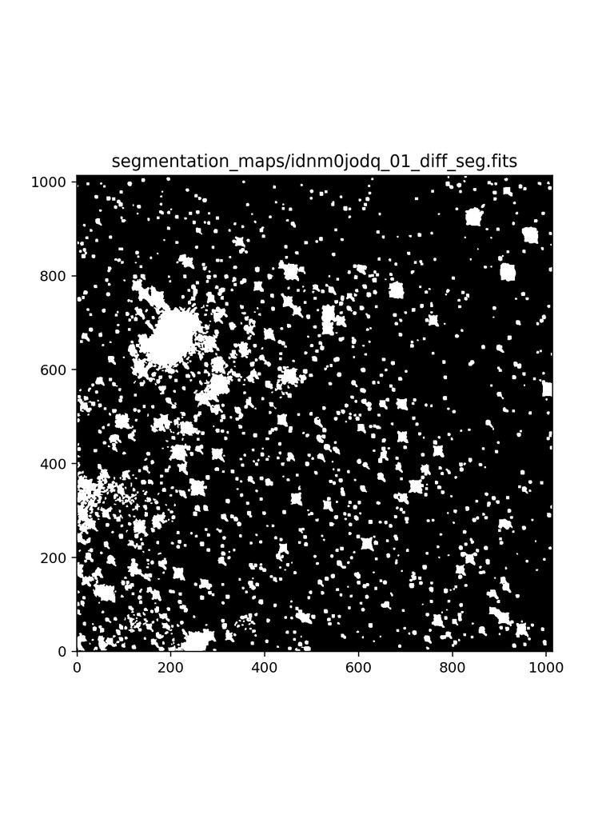

```python
segmap_name = ('segmentation_maps/' + rootname + '_01_diff_seg.fits')
segmap = fits.getdata(segmap_name)
fig = plt.figure(figsize=(6, 8))
plt.title(segmap_name)
plt.imshow(segmap, origin='lower', vmin=0, vmax=1, cmap='Greys_r')
```

### 3.5 Subtract background from difference files

Subtract background from the individual reads taken from the original IMA file using the DRZ and SEG images produced in the background subtraction of the original FLT.

By default, `subtract_background_reads()` will subtract the background and write it to the header. By setting `subtract=False`, the background will not be subtracted and will only be written to the header. In addition, setting `reset_stars_dq=True` will reset cosmic rays within objects to 0 since the centers of the stars are flagged.

```python
myDash.subtract_background_reads()
```

```
Background subtraction, diff/idnm0jodq_01_diff.fits:  2.813624858856201
Background subtraction, diff/idnm0jodq_02_diff.fits:  2.7514216899871826
Background subtraction, diff/idnm0jodq_03_diff.fits:  2.7304940223693848
Background subtraction, diff/idnm0jodq_04_diff.fits:  2.7150566577911377
Background subtraction, diff/idnm0jodq_05_diff.fits:  2.6952004432678223
Background subtraction, diff/idnm0jodq_06_diff.fits:  2.711289882659912
Background subtraction, diff/idnm0jodq_07_diff.fits:  2.6911044120788574
Background subtraction, diff/idnm0jodq_08_diff.fits:  2.688969850540161
Background subtraction, diff/idnm0jodq_09_diff.fits:  2.695927619934082
Background subtraction, diff/idnm0jodq_10_diff.fits:  2.707453489303589
Background subtraction, diff/idnm0jodq_11_diff.fits:  2.67128849029541
Background subtraction, diff/idnm0jodq_12_diff.fits:  2.6533260345458984
Background subtraction, diff/idnm0jodq_13_diff.fits:  2.64569091796875
Background subtraction, diff/idnm0jodq_14_diff.fits:  2.643061399459839
```

### 3.6 Fix cosmic rays

Now, we can use `fix_cosmic_rays()` to reset cosmic rays within the segmentation maps of objects and use [L.A.Cosmic](https://arxiv.org/pdf/astro-ph/0108003.pdf) to find them again.

```python
myDash.fix_cosmic_rays()
```

```
Starting 4 L.A.Cosmic iterations
Iteration 1:
919 cosmic pixels this iteration
Iteration 2:
224 cosmic pixels this iteration
Iteration 3:
203 cosmic pixels this iteration
Iteration 4:
176 cosmic pixels this iteration
```

### 3.7 Align reads to each other

Align reads from the IMA to one another by aligning each difference file to the first diff file.

Listed below are all the parameters available to `myDash.align()`. `align()` uses `TweakReg` to update the WCS information in the headers of the diff files, then drizzles the images together using `AstroDrizzle`. There are more parameters available to users when working with `TweakReg` and `AstroDrizzle` that could be an integral part of the workflow for users of DASH. The example below lists the default values set for every input:

`myDash.align(self, subtract_background = True, align_method = None, ref_catalog = None, create_diff_source_lists = True, updatehdr = True, updatewcs = True, wcsname = 'DASH', threshold = 50., cw = 3.5, searchrad = 20., astrodriz = True, cat_file = 'catalogs/diff_catfile.cat', drz_output = None, move_files = False)`

Refer to documentation to customize parameters for [TweakReg](https://drizzlepac.readthedocs.io/en/latest/tweakreg.html) and [AstroDrizzle](https://drizzlepac.readthedocs.io/en/latest/astrodrizzle.html).

Note: the error `UnboundLocalError: local variable 'sig' referenced before assignment` can be solved by lowering threshold parameter.

```python
myDash.align(updatehdr=False, updatewcs=True, astrodriz=False)
```

```
Keyword BG_SUB already set to Yes. Skipping background subtraction.
Background subtraction, diff/idnm0jodq_01_diff.fits:  0.041924118995666504
Keyword BG_SUB already set to Yes. Skipping background subtraction.
Background subtraction, diff/idnm0jodq_02_diff.fits:  0.03253495693206787
Keyword BG_SUB already set to Yes. Skipping background subtraction.
Background subtraction, diff/idnm0jodq_03_diff.fits:  0.028515100479125977
Keyword BG_SUB already set to Yes. Skipping background subtraction.
Background subtraction, diff/idnm0jodq_04_diff.fits:  0.029613614082336426
Keyword BG_SUB already set to Yes. Skipping background subtraction.
Background subtraction, diff/idnm0jodq_05_diff.fits:  0.029791593551635742
Keyword BG_SUB already set to Yes. Skipping background subtraction.
Background subtraction, diff/idnm0jodq_06_diff.fits:  0.0292356014251709
Keyword BG_SUB already set to Yes. Skipping background subtraction.
Background subtraction, diff/idnm0jodq_07_diff.fits:  0.03036785125732422
Keyword BG_SUB already set to Yes. Skipping background subtraction.
Background subtraction, diff/idnm0jodq_08_diff.fits:  0.025409698486328125
Keyword BG_SUB already set to Yes. Skipping background subtraction.
Background subtraction, diff/idnm0jodq_09_diff.fits:  0.03694748878479004
Keyword BG_SUB already set to Yes. Skipping background subtraction.
Background subtraction, diff/idnm0jodq_10_diff.fits:  0.02998208999633789
Keyword BG_SUB already set to Yes. Skipping background subtraction.
Background subtraction, diff/idnm0jodq_11_diff.fits:  0.028027772903442383
Keyword BG_SUB already set to Yes. Skipping background subtraction.
Background subtraction, diff/idnm0jodq_12_diff.fits:  0.02711629867553711
Keyword BG_SUB already set to Yes. Skipping background subtraction.
Background subtraction, diff/idnm0jodq_13_diff.fits:  0.027564048767089844
Keyword BG_SUB already set to Yes. Skipping background subtraction.
Background subtraction, diff/idnm0jodq_14_diff.fits:  0.033551573753356934
Setting up logfile :  tweakreg.log
TweakReg Version 3.5.0 started at: 12:45:32.853 (31/01/2023)

Version Information
--------------------
Python Version 3.10.6 | packaged by conda-forge | (main, Aug 22 2022, 20:41:54) [Clang 13.0.1 ]
numpy Version -> 1.23.4
astropy Version -> 5.1.1
stwcs Version -> 1.7.2

Restoring WCS solutions to original state using updatewcs...

```

[output cut: 843 more lines]

```
Computed  rscale  fit for  /Users/cmartlin/Desktop/local_github_repos/WFC3Library/notebooks/dash/diff/idnm0jodq_14_diff.fits :
XSH: -15.7417  YSH: 16.8730    ROT: 0.001402533414    SCALE: 0.999992
FIT XRMS: 0.2        FIT YRMS: 0.19
FIT RMSE: 0.28       FIT MAE: 0.23

RMS_RA: 7.3e-06 (deg)   RMS_DEC: 9.2e-06 (deg)

Final solution based on  815  objects.
wrote XY data to:  idnm0jodq_14_diff_catalog_fit.match
Total # points: 815
# of points after clipping: 815
Total # points: 815
# of points after clipping: 815
Writing out shiftfile : shifts/shifts_idnm0jodq.txt
Trailer file written to:  tweakreg.log
```

Print the shifts file to analyze how well the alignment went. Do not update header until shifts, as seen in the `xrms` and `yrms` columns, are satisfactory. Further information about the outputs in the shift file and what is 'satisfactory' can be found in the [Drizzlepac Handbook](https://hst-docs.stsci.edu/drizzpac).

```python
shift_file = glob('shifts/shifts_*.txt')
shift_file_name = shift_file[0]


shift_tab = Table.read(shift_file_name,
                       format='ascii.no_header',
                       names=['file','dx','dy','rot','scale','xrms','yrms'])

formats = ['.2f', '.2f', '.3f', '.5f', '.2f', '.2f']
for i, col in enumerate(shift_tab.colnames[1:]):
    shift_tab[col].format = formats[i]
shift_tab
```

*Table length=14*

| file str97 | dx float64 | dy float64 | rot float64 | scale float64 | xrms float64 | yrms float64 |
| --- | --- | --- | --- | --- | --- | --- |
| /Users/cmartlin/Desktop/local_github_repos/WFC3Library/notebooks/dash/diff/idnm0jodq_01_diff.fits | 0.00 | 0.00 | 0.000 | 1.00000 | 0.00 | 0.00 |
| /Users/cmartlin/Desktop/local_github_repos/WFC3Library/notebooks/dash/diff/idnm0jodq_02_diff.fits | -0.98 | 1.01 | 359.999 | 0.99998 | 0.17 | 0.16 |
| /Users/cmartlin/Desktop/local_github_repos/WFC3Library/notebooks/dash/diff/idnm0jodq_03_diff.fits | -2.32 | 2.40 | 0.001 | 0.99999 | 0.18 | 0.16 |
| /Users/cmartlin/Desktop/local_github_repos/WFC3Library/notebooks/dash/diff/idnm0jodq_04_diff.fits | -3.40 | 3.61 | 359.998 | 0.99995 | 0.17 | 0.17 |
| /Users/cmartlin/Desktop/local_github_repos/WFC3Library/notebooks/dash/diff/idnm0jodq_05_diff.fits | -4.76 | 5.09 | 0.001 | 0.99996 | 0.19 | 0.19 |
| /Users/cmartlin/Desktop/local_github_repos/WFC3Library/notebooks/dash/diff/idnm0jodq_06_diff.fits | -5.82 | 6.19 | 0.000 | 0.99997 | 0.22 | 0.19 |
| /Users/cmartlin/Desktop/local_github_repos/WFC3Library/notebooks/dash/diff/idnm0jodq_07_diff.fits | -6.36 | 6.82 | 0.002 | 0.99997 | 0.20 | 0.19 |
| /Users/cmartlin/Desktop/local_github_repos/WFC3Library/notebooks/dash/diff/idnm0jodq_08_diff.fits | -7.02 | 7.53 | 0.001 | 0.99994 | 0.19 | 0.18 |
| /Users/cmartlin/Desktop/local_github_repos/WFC3Library/notebooks/dash/diff/idnm0jodq_09_diff.fits | -8.48 | 9.18 | 0.001 | 0.99994 | 0.22 | 0.21 |
| /Users/cmartlin/Desktop/local_github_repos/WFC3Library/notebooks/dash/diff/idnm0jodq_10_diff.fits | -10.64 | 11.48 | 0.001 | 0.99999 | 0.21 | 0.20 |
| /Users/cmartlin/Desktop/local_github_repos/WFC3Library/notebooks/dash/diff/idnm0jodq_11_diff.fits | -11.69 | 12.43 | 0.002 | 0.99999 | 0.20 | 0.18 |
| /Users/cmartlin/Desktop/local_github_repos/WFC3Library/notebooks/dash/diff/idnm0jodq_12_diff.fits | -13.12 | 13.97 | 0.001 | 0.99997 | 0.21 | 0.19 |
| /Users/cmartlin/Desktop/local_github_repos/WFC3Library/notebooks/dash/diff/idnm0jodq_13_diff.fits | -14.78 | 15.77 | 0.001 | 0.99996 | 0.21 | 0.21 |
| /Users/cmartlin/Desktop/local_github_repos/WFC3Library/notebooks/dash/diff/idnm0jodq_14_diff.fits | -15.74 | 16.87 | 0.001 | 0.99999 | 0.20 | 0.19 |

Let's align our images with a threshold of 20, and update the headers and WCS information.

```python
myDash.align(threshold = 20.)
```

```
Keyword BG_SUB already set to Yes. Skipping background subtraction.
Background subtraction, diff/idnm0jodq_01_diff.fits:  0.041924118995666504
Keyword BG_SUB already set to Yes. Skipping background subtraction.
Background subtraction, diff/idnm0jodq_02_diff.fits:  0.03253495693206787
Keyword BG_SUB already set to Yes. Skipping background subtraction.
Background subtraction, diff/idnm0jodq_03_diff.fits:  0.028515100479125977
Keyword BG_SUB already set to Yes. Skipping background subtraction.
Background subtraction, diff/idnm0jodq_04_diff.fits:  0.029613614082336426
Keyword BG_SUB already set to Yes. Skipping background subtraction.
Background subtraction, diff/idnm0jodq_05_diff.fits:  0.029791593551635742
Keyword BG_SUB already set to Yes. Skipping background subtraction.
Background subtraction, diff/idnm0jodq_06_diff.fits:  0.0292356014251709
Keyword BG_SUB already set to Yes. Skipping background subtraction.
Background subtraction, diff/idnm0jodq_07_diff.fits:  0.03036785125732422
Keyword BG_SUB already set to Yes. Skipping background subtraction.
Background subtraction, diff/idnm0jodq_08_diff.fits:  0.025409698486328125
Keyword BG_SUB already set to Yes. Skipping background subtraction.
Background subtraction, diff/idnm0jodq_09_diff.fits:  0.03694748878479004
Keyword BG_SUB already set to Yes. Skipping background subtraction.
Background subtraction, diff/idnm0jodq_10_diff.fits:  0.02998208999633789
Keyword BG_SUB already set to Yes. Skipping background subtraction.
Background subtraction, diff/idnm0jodq_11_diff.fits:  0.028027772903442383
Keyword BG_SUB already set to Yes. Skipping background subtraction.
Background subtraction, diff/idnm0jodq_12_diff.fits:  0.02711629867553711
Keyword BG_SUB already set to Yes. Skipping background subtraction.
Background subtraction, diff/idnm0jodq_13_diff.fits:  0.027564048767089844
Keyword BG_SUB already set to Yes. Skipping background subtraction.
Background subtraction, diff/idnm0jodq_14_diff.fits:  0.033551573753356934
Setting up logfile :  tweakreg.log
TweakReg Version 3.5.0 started at: 12:46:16.731 (31/01/2023)

Version Information
--------------------
Python Version 3.10.6 | packaged by conda-forge | (main, Aug 22 2022, 20:41:54) [Clang 13.0.1 ]
numpy Version -> 1.23.4
astropy Version -> 5.1.1
stwcs Version -> 1.7.2

Restoring WCS solutions to original state using updatewcs...

AstrometryDB service available...
```

[output not shown]

[output not shown]

[output not shown]

[output not shown]

[output not shown]

[output not shown]

[output not shown]

[output not shown]

[output not shown]

[output not shown]

[output not shown]

[output not shown]

[output not shown]

[output not shown]

[output not shown]

[output not shown]

[output not shown]

[output not shown]

[output not shown]

[output not shown]

[output not shown]

[output not shown]

[output not shown]

[output not shown]

[output not shown]

[output not shown]

[output not shown]

[output not shown]

[output cut: 999 more lines]

```
                   Step          Elapsed time
   --------------------          --------------------

         Initialization          1.4327 sec.
            Static Mask          0.2933 sec.
           Subtract Sky          1.1414 sec.
       Separate Drizzle          3.6770 sec.
          Create Median          1.7667 sec.
                   Blot          2.4246 sec.
                Driz_CR          1.1879 sec.
          Final Drizzle          4.5646 sec.
   ====================          ====================
                  Total          16.4882 sec.

Trailer file written to:  astrodrizzle.log
```

## 4. Plot original IMA and DASH pipeline science result

Plot the final DRZ image and compare to the original IMA.

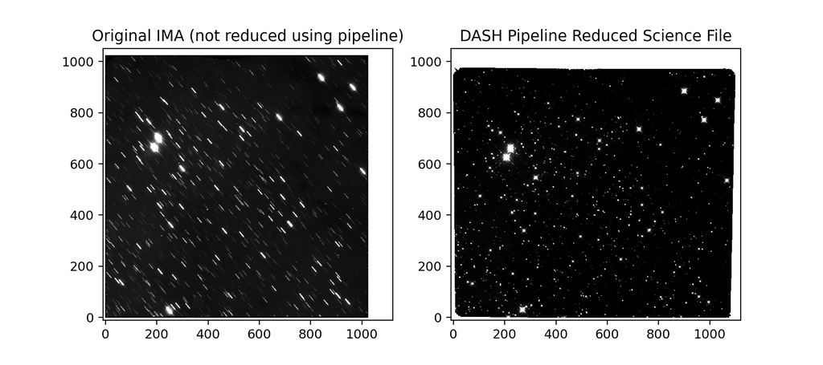

```python
sci_name = myDash.root + '_drz_sci.fits'
og_flt_name = 'mastDownload/HST/' + myDash.root + '/' + myDash.root + '_ima.fits'
sci = fits.getdata(sci_name)
og_flt = fits.getdata(og_flt_name)

fig = plt.figure(figsize=(9, 4))
ax1 = fig.add_subplot(1,2,2)
ax2 = fig.add_subplot(1,2,1)

ax1.set_title('DASH Pipeline Reduced Science File')
ax2.set_title('Original IMA (not reduced using pipeline)')

ax1.set_xlim(-10,1120)
ax2.set_xlim(-10,1120)

ax1.set_ylim(-10,1050)
ax2.set_ylim(-10,1050)

ax1.imshow(sci, vmin=0, vmax=40, cmap='Greys_r', origin='lower')
ax2.imshow(og_flt, vmin=0, vmax=40, cmap='Greys_r', origin='lower')
plt.show()
```

## 5. Conclusions

Thank you for walking through this notebook. Now using WFC3 data, you should be more familiar with:

- Creating difference files, association tables, and segmentation maps using `wfc3_dash`.
- Subtracting background and fixing cosmic rays from newly generated FLTs.
- Aligning reads to each other for a final product.

Congratulations, you have completed the notebook!

## Additional Resources

Below are some additional resources that may be helpful. Please send any questions through the [HST Helpdesk](https://stsci.service-now.com/hst).

- [WFC3 Website](https://www.stsci.edu/hst/instrumentation/wfc3)
- [WFC3 Instrument Handbook](https://hst-docs.stsci.edu/wfc3ihb)
- [WFC3 Data Handbook](https://hst-docs.stsci.edu/wfc3dhb)
  - see sections 9.5.4 for reference to this notebook

## About this Notebook

**Authors:** Catherine Martlin; WFC3 Instrument Team

**Updated on:** 2023-01-25

## Citations

If you use `numpy`, `matplotlib`, `astropy`, `astroquery`, `photutils`, or `drizzlepac` for published research, please cite the authors. Follow these links for more information about citing the libraries below:

- [Citing `numpy`](https://numpy.org/citing-numpy/)
- [Citing `matplotlib`](https://matplotlib.org/stable/users/project/citing.html)
- [Citing `astropy`](https://www.astropy.org/acknowledging.html)
- [Citing `astroquery`](https://astroquery.readthedocs.io/en/latest/license.html)
- [Citing `photutils`](https://photutils.readthedocs.io/en/stable/citation.html)
- [Citing `drizzlepac`](https://drizzlepac.readthedocs.io/en/latest/LICENSE.html)

Top of Page